# Exercise 6 - Advanced Statistics for Physics Analysis (A.Y. 2022-2023)

by Erica Brisigotti (2097202)

## Exercise 1

Given the following un-normalized posterior distribution

$$ g(\theta | x) \propto \frac{1}{2} \exp\left(-\frac{(\theta+3)^2}{2}\right) + \frac{1}{2} \exp\left(-\frac{(\theta-3)^2}{2}\right) $$

I find the norm of the un-normalized posterior by integrating analytically $$ \left| g \right| = \int_{-\infty}^{+\infty} \exp(\left(-\frac{(\theta+3)^2}{2}\right)) \; d\theta + \int_{-\infty}^{+\infty} \exp(\left(-\frac{(\theta^\prime-3)^2}{2}\right)) \; d\theta^\prime $$ By applying two changes of variable $ \theta+3 \rightarrow t $ and $ \theta^\prime+3 \rightarrow s $, I notice that the two integrals correspond to the same Gaussian integral: $$ \left| g \right| = \int_{-\infty}^{+\infty} \exp(\left(-\frac{t^2}{2}\right)) \; dt + \int_{-\infty}^{+\infty} \exp(\left(-\frac{s^2}{2}\right)) \; ds = 2 \int_{-\infty}^{+\infty} \exp(\left(-\frac{s^2}{2}\right)) \; ds = 2\sqrt{2\pi} $$

```r
# I define the normalized posterior distribution
# by initializing the norm of the un-normalized posterior distribution
log_post_int <- 2*(2*pi)**0.5
# and dividing the un-normalized posterior distribution by said norm
log_post <- function(theta){ log(0.5 * exp(-(theta + 3)^2 / 2) + 0.5 * exp(-(theta - 3)^2 / 2)) /log_post_int }
```

- draw a Markov Chain from the posterior distribution using a Metropolis-Hastings algorithm

```r
# I assume a uniform distribution of the proposed values
proposal <- function(theta, sigma){ (rnorm(1, mean = theta, sd = sigma)) }
```

```r
# and initialize the function that executes the Metropolis-Hastings algorithm
metropolis_hastings <- function(num_iterations, initial_theta, scale) {
    # I set its starting values
    theta <- initial_theta
    # and initialize the variables that will be modified during the iteration, which are
    # an array in which I'm going to save the values of theta
    chain <- numeric(num_iterations)
    # and a counter for the number of accepted values of theta
    accepted <- 0
    # At every iteration
    for (i in 1:num_iterations) {
        # I propose a value for the parameter theta based on the previously defined proposal function
        proposed_theta <- proposal(theta, scale)
        # I calculate the logarithm of the ration betweent the posterior probabilities
        log_ratio <- log_post(proposed_theta) - log_post(theta)
        # and ensure that the probability is less or equal to 1
        acceptance_prob <- min(1, exp(log_ratio))
        # I then extract a random number
        u <- runif(1)
        # based on which I decide weather or not to accept the value of theta or not
        if (u < acceptance_prob){
            # whenever I accept, I update the value of theta to the one proposed
            theta <- proposed_theta
            # and update the updated counter
            accepted <- accepted + 1 }
        # otherwise (if I don't accept) the values of theta and counter are unchanged
        chain[i] <- theta }
    # lastly, I calculate the acceptance probability
    acceptance_rate <- accepted / num_iterations
    # and structure the data that I want to store in a list (because of lists flexibility)
    result <- list(chain = chain, acceptance_rate = acceptance_rate)
    return(result) }
```

- use a Norm$(0,1)$ as random-walk candidate density

```r
# now, I just have to set the parameters of my simulation
num_iterations <- 1000000
initial_theta <- 0
sigma <- 1
# and finally run it
result <- metropolis_hastings(num_iterations, initial_theta, sigma)
# the results are the following
cat("the acceptance rate of the MCMC algorithm is", result$acceptance_rate*100, "%. \n")
```

```
the acceptance rate of the MCMC algorithm is 88.665 %.
```

- plot the sampled distribution

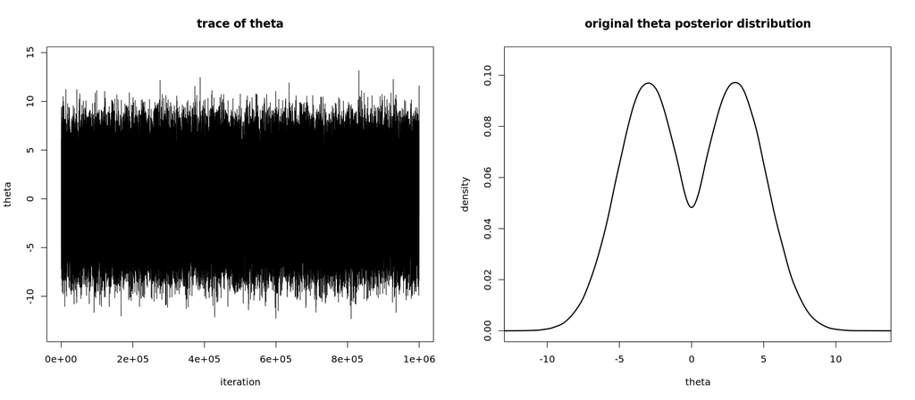

```r
# I decide to represent the trace of th MCMC
options(repr.plot.width=16, repr.plot.height=7)
par( mfrow=c(1,2) )
plot(result$chain, type = "l", xlab = "iteration", ylab = "theta", col="black", ylim=1.1*c(min(result$chain),max(result$chain)),
     main = "trace of theta")
# and the density/distribution of the MCMC parameter theta
dens <- density(result$chain)
plot(dens$x, dens$y, type="l", lwd=2, xaxs="i", col="black", ylim=1.1*c(0,max(dens$y)), xlab='theta', ylab="density",
    main = "original theta posterior distribution")
```

- analyze the chain with the CODA package and plot the chain autocorrelation

```r
library(coda)
```

```
Iterations = 1:1e+06
Thinning interval = 1
Number of chains = 1
Sample size per chain = 1e+06

1. Empirical mean and standard deviation for each variable,
   plus standard error of the mean:

          Mean             SD       Naive SE Time-series SE
    -0.0001732      3.8758881      0.0038759      0.0356186

2. Quantiles for each variable:

      2.5%        25%        50%        75%      97.5%
-6.7633337 -3.2319083  0.0001085  3.2367856  6.7333728
```

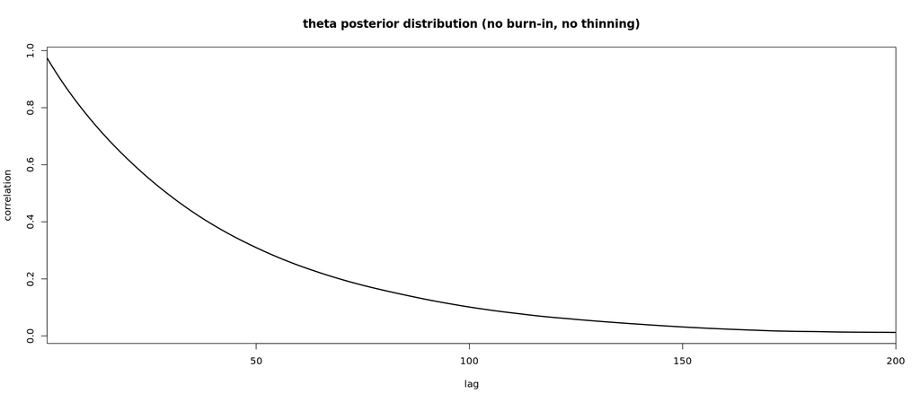

```r
# I save my chain in a dataframe format
c <- as.mcmc( result$chain )
# and get a summary statistics of the parameter of the MCMC chain
summary(c)
# and plot the chain autocorrelation plot
options(repr.plot.width=16, repr.plot.height=7)
ac <- autocorr(c, lags = 1:200)
plot(ac, type="l", lwd=2, xaxs="i", col="black", xlab='lag', ylab="correlation",
    main = "theta posterior distribution (no burn-in, no thinning)")
```

The original chain could be less auto-correlated.

- try to use different burn-in cycles and thinning and plot the corresponding posterior distribution and the chain autocorrelation function. What are the best parameters ?

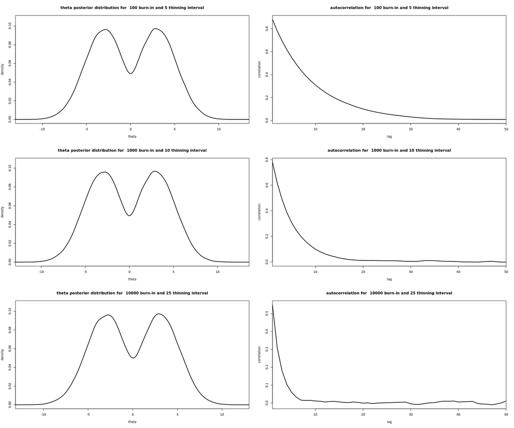

```r
# I select some values for the burn-in
burn_in_values = c(0.01, 0.1, 1)*num_iterations/100
# and for the thinning intervals
thinning_intervals = c(0.0005, 0.001, 0.0025)*num_iterations/100

# I configure the plots
options(repr.plot.width=18, repr.plot.height=15)
par( mfrow=c(3,2) )
# for every combination of parameters
for (i in 1:3){
    # I crop the burn-in
    temp <- result$chain[seq(burn_in_values[i]+1,length(result$chain),1)]
    # and thin the burned vector
    idx <- seq(1, length(temp), thinning_intervals[i])
    temp <- temp[idx]
    # I plot the posterior distribution
    dens <- density(temp)
    plot(dens$x, dens$y, type="l", lwd=2, xaxs="i", col="black", ylim=1.1*c(0,max(dens$y)), xlab='theta', ylab="density",
        main = paste("theta posterior distribution for ",burn_in_values[i],'burn-in and',thinning_intervals[i],
                     'thinning interval'))
    # and the auto-correlation function
    c <- as.mcmc( temp )
    ac <- autocorr(c, lags = 1:50)
    plot(ac, type="l", lwd=2, xaxs="i", col="black", xlab='lag', ylab="correlation",
        main = paste("autocorrelation for ",burn_in_values[i],'burn-in and',thinning_intervals[i],
                     'thinning interval'))
}
```

The burn-in and thinning strategy definitely helped reduce the auto-correlatation.

## Exercise 2

The European Medicines Agency (EMA) has authorized a list of COVID-19 vaccines, after having performed a scientific evaluation of the vaccines efficacy. The following vaccines are currently authorized for use in the European Union:

- Comirnaty (BioNTech and Pfizer)
- VCOVID-19 Vaccine Valneva
- Nuvaxovid (Novavax)
- Pikevax (Moderna)
- Vaxzeviria (AstraZeneca)
- Jcovden (Janssen)
- VidPrevtyn Beta (Sanofi Pasteur)
- Bimervax, previously COVID-19 Vaccine HIPRA (HIPRA Human Health S.L.U.)

Analyze the initial test data reported on the EMA Web site for the following early Vaccines

- Janssen [1]
- Moderna [2]
- AstraZeneca [3]
- Jcovden [4]

and create a Markow Chain Monte Carlo JAGS or stan the efficacy of each vaccine. Infere the 95% credibility interval.

I notice online that Janssen seems to be just the old name for Jcovden, so I will have to analyze just three cases instead of four.I summarize the analysis into a function to make the code more readable, and apply it to each case later on.

```r
library(tidyverse)
library(rjags)
library(bayestestR)
library(logspline)
```

```
Linked to JAGS 4.3.0

Loaded modules: basemod,bugs
```

```r
# I initialize the model without external files
model_text <- "
    model {
    # it's a bernoulli inference problem, so I use the bernoulli distribution
    # to compute the likelihood
    for ( i in 1:Ntot ) {
    tested[i] ~ dbern( theta[patient[i]] )
    }
    # I do not use a flat prior, since we know how likely is to get COVID.
    # I use a beta(3,100) prior:
    for ( k in 1:Nclass ) {
        theta[k] ~ dbeta(3 , 100)
        }
    }"
```

```r
my_Vaccine_analysis <- function(string){
    # for Moderna
    if (string == 'Moderna'){
        tot_vaccine <- 14134
        tot_placebo <- 14073
        pos_vaccine <- 11
        pos_placebo <- 185
    # for AstraZeneca
    } else if (string == 'AstraZeneca'){
        tot_vaccine <- 5258
        tot_placebo <- 5210
        pos_vaccine <- 64
        pos_placebo <- 154
    # for Jcovden aka Janssen
    } else if (any(string == c('Jcovden','Janssen'))) {
        tot_vaccine <- 19630
        tot_placebo <- 19691
        pos_vaccine <- 116
        pos_placebo <- 348
    } else {
        stop('no info about this vaccine, please initialize in the function')
    }
    patient <- c(rep("Vaccine", tot_vaccine),
                 rep("Placebo", tot_placebo))
    tested <- c(rep("Pos", pos_vaccine),
                rep("Neg", tot_vaccine - pos_vaccine),
                rep("Pos", pos_placebo),
                rep("Neg", tot_placebo - pos_placebo))
    tb <- tibble(tested = tested , patient=patient)

    # I print the pieces of info about the plot
    print(table(tb[[2]], tb[[1]]))

    # I initialize the data for the MCMC model
    data = list(
        tested = ifelse(tb$tested == "Neg", 0, 1),
        patient = as.integer(factor(tb$patient)),
        Ntot = nrow(tb) ,
        Nclass = nlevels(factor(tb$patient )) )
    # initialize such model through rjags
    model <- jags.model( file = textConnection(model_text),
                         data = data,
                         quiet = TRUE )
    # and run the model to get the samples to analyze
    chains <- coda.samples( model,
                            var = "theta",
                            n.iter = 50000 )
    # I transform the output into a dataframe for the custom plots
    df <- as.data.frame( as.mcmc(chains) )
    colnames(df) <- c('Placebo', 'Vaccine')
    # and display a quick summary statistics of the results
    temp <- summary(chains)
    print(temp)

    # I intialize the plot
    options(repr.plot.width=18, repr.plot.height=18)
    par( mfrow=c(3,2) )
    # I plot the trace and average of the Placebo
    mean <- temp$statistics['theta[1]','Mean']
    plot(df$Placebo, type = "l", xlab = "iteration", ylab = "theta", col="black", ylim=c(min(df$Placebo),max(df$Placebo)),
         xaxs="i", main = paste("trace of theta for Placebo patients -", string, 'vaccine'))
    abline(h=mean, col='red', lwd=2, lty=2)
    legend('topright', legend=c("trace","average"), col=c('black','red'), lty = c(1, 2), lwd=c(1, 2), cex = 0.8)
    # and of the Vaccine
    mean <- temp$statistics['theta[2]','Mean']
    plot(df$Vaccine, type = "l", xlab = "iteration", ylab = "theta", col="black", ylim=c(min(df$Vaccine),max(df$Vaccine)),
         xaxs="i", main = paste("trace of theta for Vaccine patients -", string, 'vaccine'))
    abline(h=mean, col='red', lwd=2, lty=2)
    legend('topright', legend=c("trace","average"), col=c('black','red'), lty = c(1, 2), lwd=c(1, 2), cex = 0.8)
    # I plot the density and 95% CI limits for the Placebo
    dens <- density( df$Placebo )
    low_lim <- temp$quantiles['theta[1]','2.5%']
    up_lim <- temp$quantiles['theta[1]','97.5%']
    plot(dens$x, dens$y, type="l", lwd=2, xaxs="i", col="black", ylim=1.1*c(0,max(dens$y)), xlab='theta', ylab="density",
        main = paste('theta distribution for Placebo patients -', string, 'vaccine'))
    abline(v=low_lim, col='green', lwd=2, lty=2)
    abline(v=up_lim, col='green', lwd=2, lty=2)
    legend('topright', legend=c("trace","95% CI"), col=c('black','green'), lty = c(1, 2), lwd=c(1, 2), cex = 0.8)
    # and for the Vaccine
    dens <- density( df$Vaccine )
    low_lim <- temp$quantiles['theta[2]','2.5%']
    up_lim <- temp$quantiles['theta[2]','97.5%']
    plot(dens$x, dens$y, type="l", lwd=2, xaxs="i", col="black", ylim=1.1*c(0,max(dens$y)), xlab='theta', ylab="density",
        main = paste('theta distribution for Vaccine patients -', string, 'vaccine'))
    abline(v=low_lim, col='green', lwd=2, lty=2)
    abline(v=up_lim, col='green', lwd=2, lty=2)
    legend('topright', legend=c("trace","95% CI"), col=c('black','green'), lty = c(1, 2), lwd=c(1, 2), cex = 0.8)
    # I plot the autocorrelatin for the Placebo
    c <- as.mcmc( df$Placebo )
    ac <- autocorr(c, lags = 1:50)
    plot(ac, type="l", lwd=2, xaxs="i", col="black", xlab='lag', ylab="correlation",
        main = paste('theta autocorrelation for Placebo patients -', string, 'vaccine'))
    # and for the Vaccine
    c <- as.mcmc( df$Vaccine )
    ac <- autocorr(c, lags = 1:50)
    plot(ac, type="l", lwd=2, xaxs="i", col="black", xlab='lag', ylab="correlation",
        main = paste('theta autocorrelation for Vaccine patients -', string, 'vaccine'))

    # to have quantitative results, I use the bayes factor
    df['diff_rate'] <- (df$Placebo - df$Vaccine) / df$Placebo * 100
    prior <- bayestestR::distribution_normal(50000, mean = 50, sd = 15)
    t <- bayestestR::bayesfactor_parameters(df$diff_rate, prior, direction = "two-sided", null = 50)
    print(t)
    }
```

```
            Neg   Pos
  Placebo 13888   185
  Vaccine 14123    11

Iterations = 1:50000
Thinning interval = 1
Number of chains = 1
Sample size per chain = 50000

1. Empirical mean and standard deviation for each variable,
   plus standard error of the mean:

              Mean        SD  Naive SE Time-series SE
theta[1] 0.0132600 0.0009607 4.296e-06      4.296e-06
theta[2] 0.0009825 0.0002630 1.176e-06      1.191e-06

2. Quantiles for each variable:

              2.5%       25%       50%      75%   97.5%
theta[1] 0.0114473 0.0125959 0.0132362 0.013897 0.01521
theta[2] 0.0005354 0.0007946 0.0009595 0.001146 0.00156

Bayes Factor (Savage-Dickey density ratio)

BF
--------
3.44e+16

* Evidence Against The Null: 50
```

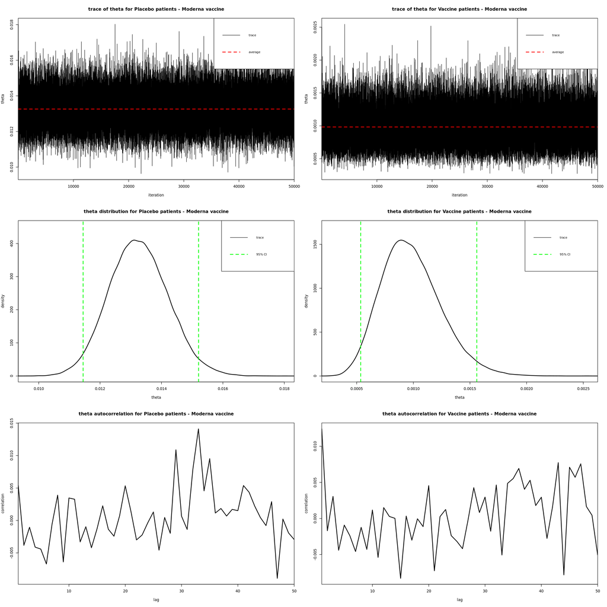

```r
my_Vaccine_analysis('Moderna')
```

The Bayes Factor is high enough to support the interpretation that "you are less likely to get COVID-19 if you have taken the Moderna vaccine".

```
           Neg  Pos
  Placebo 5056  154
  Vaccine 5194   64

Iterations = 1:50000
Thinning interval = 1
Number of chains = 1
Sample size per chain = 50000

1. Empirical mean and standard deviation for each variable,
   plus standard error of the mean:

            Mean       SD  Naive SE Time-series SE
theta[1] 0.02956 0.002325 1.040e-05      1.066e-05
theta[2] 0.01250 0.001513 6.766e-06      6.766e-06

2. Quantiles for each variable:

             2.5%     25%     50%     75%   97.5%
theta[1] 0.025165 0.02795 0.02949 0.03109 0.03427
theta[2] 0.009714 0.01145 0.01243 0.01348 0.01564

Bayes Factor (Savage-Dickey density ratio)

BF
-----
0.958

* Evidence Against The Null: 50
```

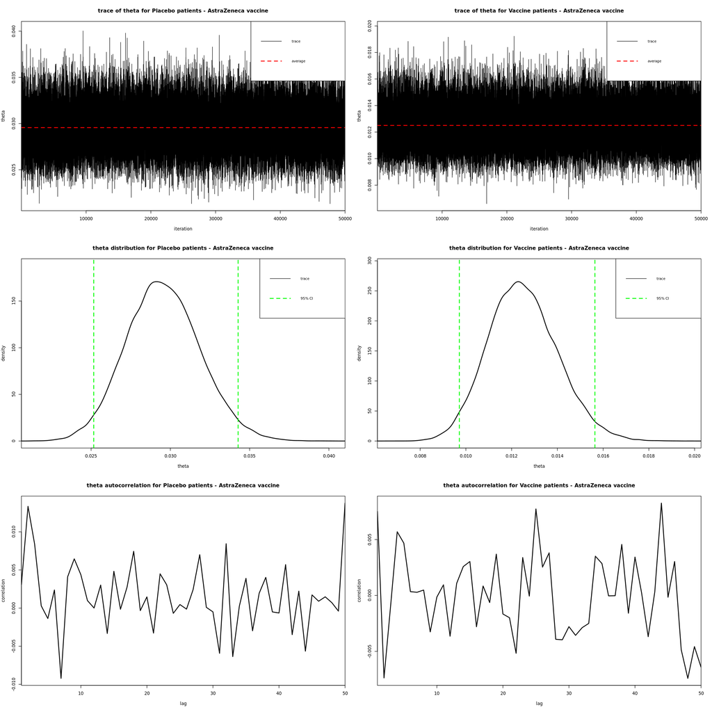

```r
my_Vaccine_analysis('AstraZeneca')
```

```
            Neg   Pos
  Placebo 19343   348
  Vaccine 19514   116

Iterations = 1:50000
Thinning interval = 1
Number of chains = 1
Sample size per chain = 50000

1. Empirical mean and standard deviation for each variable,
   plus standard error of the mean:

             Mean        SD  Naive SE Time-series SE
theta[1] 0.017737 0.0009351 4.182e-06      4.182e-06
theta[2] 0.006028 0.0005491 2.456e-06      2.522e-06

2. Quantiles for each variable:

             2.5%      25%      50%      75%    97.5%
theta[1] 0.015957 0.017094 0.017719 0.018353 0.019628
theta[2] 0.005005 0.005651 0.006008 0.006386 0.007157

Bayes Factor (Savage-Dickey density ratio)

BF
------
260.49

* Evidence Against The Null: 50
```

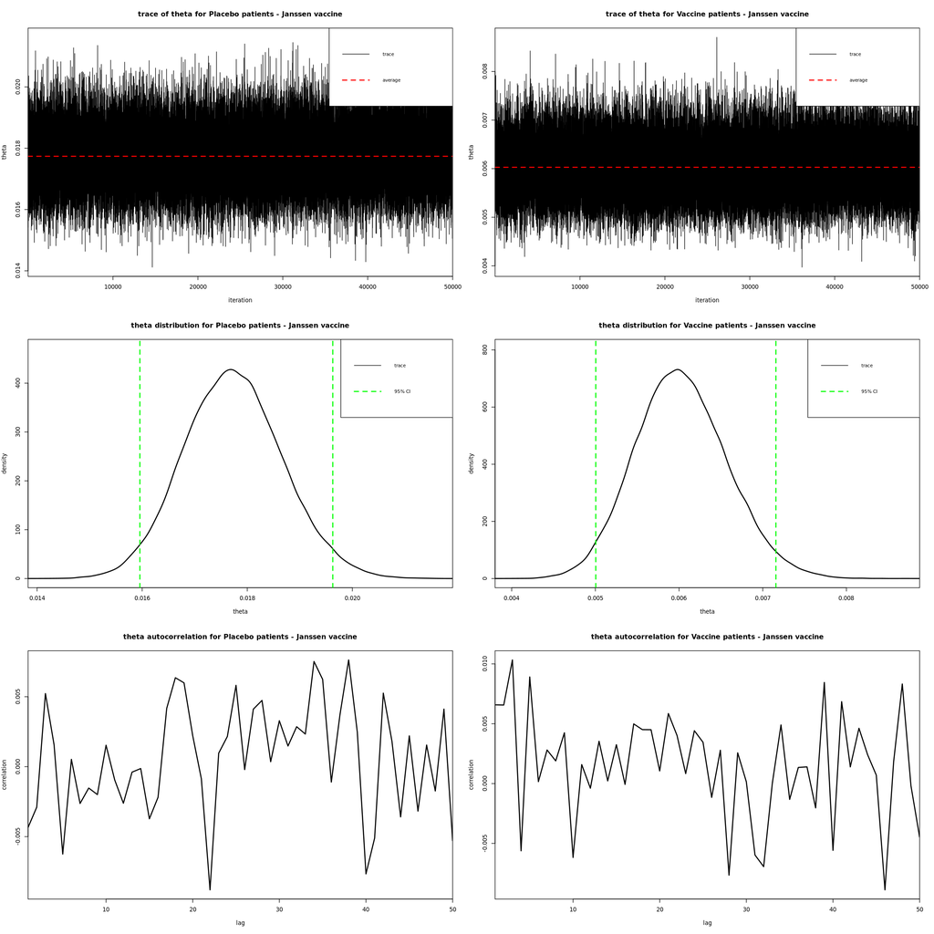

```r
my_Vaccine_analysis('Janssen')
```

The Bayes Factor is high enough to support the interpretation that "you are less likely to get COVID-19 if you have taken the Janssen/Jcovden vaccine".

## Exercise 3

According to the official COVID-19 vaccination data, 70% of the world population has received at least one dose of a COVID-19 vaccine. A global vaccination dataset is available [5]. The European Centre for Disease Prevention and Control published a downloadable file [6] containing information on COVID-19 vaccination in the EU/EEA.

Analyze the data and produce the following plots:

- number of vaccinated people (cumulative, daily and week average)

```r
library('tidyverse')
```

```r
# I upload the data
df = read.csv( 'vaccinations.csv')
head(df)
```

A data.frame: 6 × 16

|  | location <chr> | iso_code <chr> | date <chr> | total_vaccinations <dbl> | people_vaccinated <dbl> | people_fully_vaccinated <dbl> | total_boosters <dbl> | daily_vaccinations_raw <int> | daily_vaccinations <int> | total_vaccinations_per_hundred <dbl> | people_vaccinated_per_hundred <dbl> | people_fully_vaccinated_per_hundred <dbl> | total_boosters_per_hundred <dbl> | daily_vaccinations_per_million <int> | daily_people_vaccinated <int> | daily_people_vaccinated_per_hundred <dbl> |
| --- | --- | --- | --- | --- | --- | --- | --- | --- | --- | --- | --- | --- | --- | --- | --- | --- |
| 1 | Afghanistan | AFG | 2021-02-22 | 0 | 0 | NA | NA | NA | NA | 0 | 0 | NA | NA | NA | NA | NA |
| 2 | Afghanistan | AFG | 2021-02-23 | NA | NA | NA | NA | NA | 1367 | NA | NA | NA | NA | 33 | 1367 | 0.003 |
| 3 | Afghanistan | AFG | 2021-02-24 | NA | NA | NA | NA | NA | 1367 | NA | NA | NA | NA | 33 | 1367 | 0.003 |
| 4 | Afghanistan | AFG | 2021-02-25 | NA | NA | NA | NA | NA | 1367 | NA | NA | NA | NA | 33 | 1367 | 0.003 |
| 5 | Afghanistan | AFG | 2021-02-26 | NA | NA | NA | NA | NA | 1367 | NA | NA | NA | NA | 33 | 1367 | 0.003 |
| 6 | Afghanistan | AFG | 2021-02-27 | NA | NA | NA | NA | NA | 1367 | NA | NA | NA | NA | 33 | 1367 | 0.003 |

```r
# I group the data on a daily basis and save the daily count and average
df %>% group_by(date) %>% summarise( total=sum(total_vaccinations, na.rm=TRUE),
                                     average=mean(daily_vaccinations, na.rm=TRUE) ) -> daily_df
```

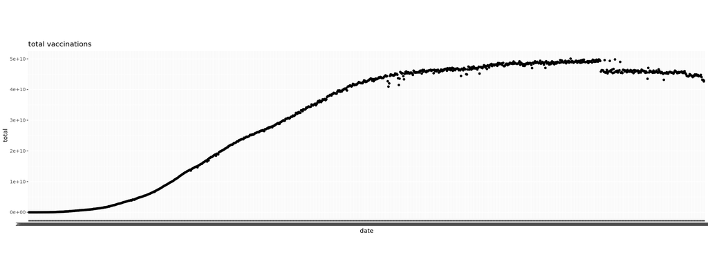

```r
# I plot the results
# for the daily cumulative sum
options(repr.plot.width=18, repr.plot.height=7)
ggplot(daily_df, aes(date, total)) + geom_point() + theme(aspect.ratio = 1/4) + ggtitle('total vaccinations')
```

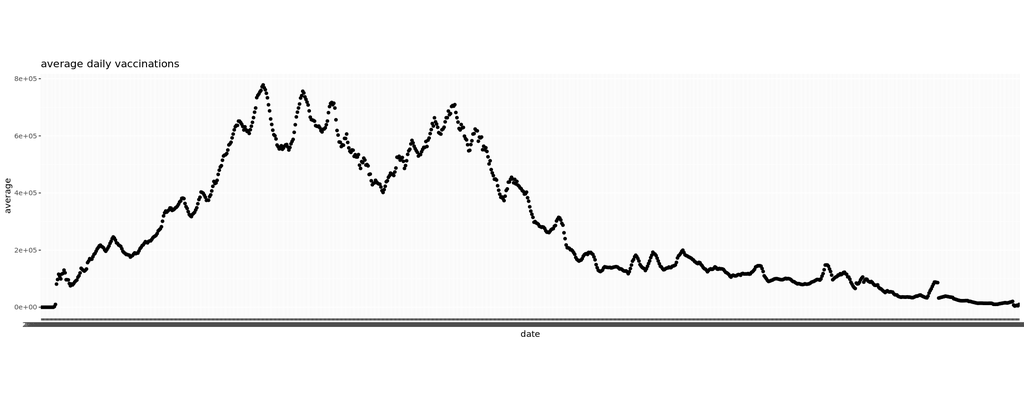

```r
# for the daily average
options(repr.plot.width=18, repr.plot.height=7)
ggplot(daily_df, aes(date, average)) + geom_point() + theme(aspect.ratio = 1/4) + ggtitle('average daily vaccinations')
```

```r
# I create a column with the number of the week
df["week"] <- strftime( df$date, format="%j" )
# so that I can group the data on a weekly basis and save
df %>% group_by( week ) %>% summarise( average = sum(daily_vaccinations, na.rm=TRUE) ) -> weekly_df
```

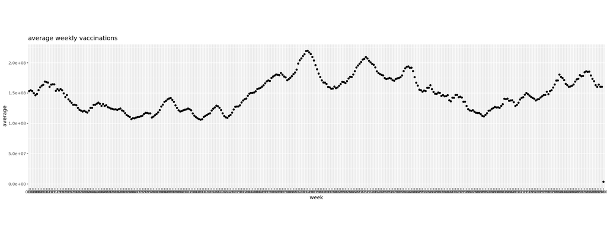

```r
# for the daily average
options(repr.plot.width=18, repr.plot.height=7)
ggplot(weekly_df, aes(week, average)) + geom_point() + theme(aspect.ratio = 1/4) + ggtitle('average weekly vaccinations')
```

- number of confirmed deaths by COVID-19, both cumulative and weekly average

```r
dataframe <- read.csv( 'weekly_deaths.csv')
head(dataframe)
```

A data.frame: 6 × 247

|  | date <chr> | World <dbl> | Afghanistan <dbl> | Africa <dbl> | Albania <dbl> | Algeria <dbl> | American.Samoa <dbl> | Andorra <dbl> | Angola <dbl> | Anguilla <dbl> | ⋯ | Uruguay <dbl> | Uzbekistan <dbl> | Vanuatu <dbl> | Vatican <dbl> | Venezuela <dbl> | Vietnam <dbl> | Wallis.and.Futuna <dbl> | Yemen <dbl> | Zambia <dbl> | Zimbabwe <dbl> |
| --- | --- | --- | --- | --- | --- | --- | --- | --- | --- | --- | --- | --- | --- | --- | --- | --- | --- | --- | --- | --- | --- |
| 1 | 2020-01-03 | NA | NA | NA | NA | NA | NA | NA | NA | NA | ⋯ | NA | NA | NA | NA | NA | NA | NA | NA | NA | NA |
| 2 | 2020-01-04 | NA | NA | NA | NA | NA | NA | NA | NA | NA | ⋯ | NA | NA | NA | NA | NA | NA | NA | NA | NA | NA |
| 3 | 2020-01-05 | NA | NA | NA | NA | NA | NA | NA | NA | NA | ⋯ | NA | NA | NA | NA | NA | NA | NA | NA | NA | NA |
| 4 | 2020-01-06 | NA | NA | NA | NA | NA | NA | NA | NA | NA | ⋯ | NA | NA | NA | NA | NA | NA | NA | NA | NA | NA |
| 5 | 2020-01-07 | NA | NA | NA | NA | NA | NA | NA | NA | NA | ⋯ | NA | NA | NA | NA | NA | NA | NA | NA | NA | NA |
| 6 | 2020-01-08 | 0 | 0 | 0 | 0 | 0 | 0 | 0 | 0 | 0 | ⋯ | 0 | 0 | 0 | 0 | 0 | 0 | 0 | 0 | 0 | 0 |

```r
# I create a column with the number of the week
dataframe["week"] <- strftime( dataframe$date, format="%j" )
# so that I can group the data on a weekly basis and save
dataframe %>% group_by( week ) %>% summarise( sum=sum(World, na.rm=TRUE), average=sum(World, na.rm=TRUE) ) -> weekly_dataframe
weekly_dataframe['cumsum'] <- cumsum(weekly_dataframe['sum'])
```

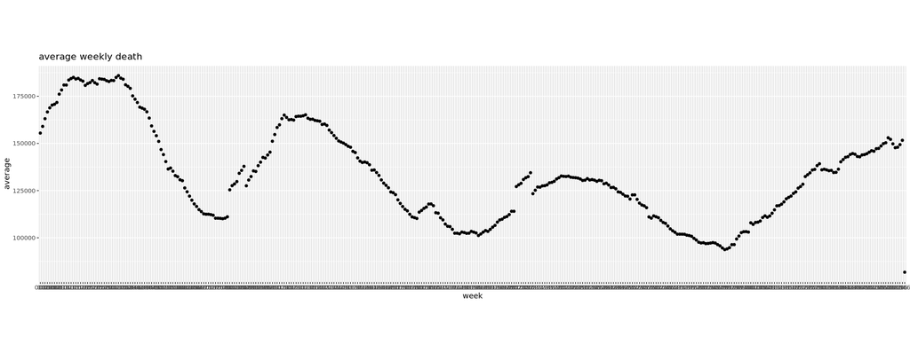

```r
# I plot the total deaths by week
options(repr.plot.width=18, repr.plot.height=7)
ggplot(weekly_dataframe, aes(week, average)) + geom_point() + theme(aspect.ratio = 1/4) + ggtitle('average weekly death')
```

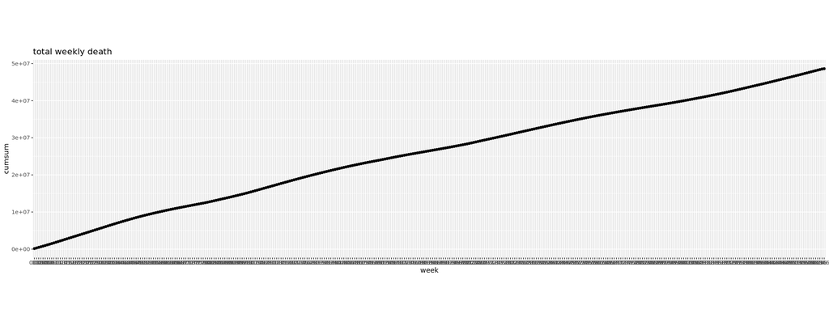

```r
# I plot the total deaths by week
options(repr.plot.width=18, repr.plot.height=7)
ggplot(weekly_dataframe, aes(week, cumsum)) + geom_point() + theme(aspect.ratio = 1/4) + ggtitle('total weekly death')
```

## References

[1] https://www.ema.europa.eu/en/documents/overview/covid-19-vaccine-janssen-epar-medicine-overview_en.pdf

[2] https://www.ema.europa.eu/en/documents/overview/spikevax-previously-covid-19-vaccine-moderna-epar-medicine-overview_en.pdf

[3] https://www.ema.europa.eu/en/documents/overview/vaxzevria-previously-covid-19-vaccine-astrazeneca-epar-medicine-overview_en.pdf

[4] https://www.ema.europa.eu/en/documents/overview/jcovden-previously-covid-19-vaccine-janssen-epar-medicine-overview_en.pdf

[5] https://ourworldindata.org/covid-vaccinations

[6] https://github.com/owid/covid-19-data/tree/master/public/data